# assignment5

Vanessa Löw

2023-03-28

```r
suppressPackageStartupMessages({
  library(AnnotationHub)
  library(rtracklayer)
  library(epiwraps)
  library(GenomicRanges)
  library(R.utils)#for function gunzip
  library(MASS) #to convert decimal to fraction
  library(knitr)
})
ah <- AnnotationHub()
```

```
## snapshotDate(): 2022-10-31
```

#Using the peaks you downloaded last week, identify bivalent domains (H3K27me3 + H3K4me3) in mouse embryonic stem cells (mESC) #Meaning find overlaps between H3K27me3 + H3K4me3

```r
H3K4me3 <- rtracklayer::import("peaks/H3K4me3.bed", format="narrowPeak")
H3K27me3 <- rtracklayer::import("peaks/H3K27me3.bed", format="narrowPeak")
bivDomains <- overlapsAny(H3K4me3,H3K27me3)
sum(bivDomains)
```

```
## [1] 174
```

```r
bivDomainsPeaks <- findOverlaps(H3K27me3,H3K4me3)
bivDomainsPeaks
```

```
## Hits object with 234 hits and 0 metadata columns:
##         queryHits subjectHits
##         <integer>   <integer>
##     [1]         2           8
##     [2]        10          10
##     [3]        13          30
##     [4]        15          42
##     [5]        25         124
##     ...       ...         ...
##   [230]       775        2800
##   [231]       782        2856
##   [232]       782        2857
##   [233]       789        2865
##   [234]       790        2865
##   -------
##   queryLength: 790 / subjectLength: 2865
```

```r
#create subset from overlapping peaks
subset <- H3K4me3[bivDomains[TRUE]]
```

#Question: what happens to those regions upon differentiation? Upon differentation, the pluripotent stem cells will ‘decide’ for one state, to monovalent states that are either activated (H3K4me3) or repressed (H3K27me3).

#Choose one differentiated cell type (e.g. hepatocytes, neural progenitor, or smooth muscle cells) #Download the H3K27me3 and H3K4me3 peaks from this cell type #Hepatocyte

```r
#H3K27me3
download.file("https://www.encodeproject.org/files/ENCFF900AWR/@@download/ENCFF900AWR.bed.gz", destfile="hepa.H3K27me3.bed.gz")
gunzip("hepa.H3K27me3.bed.gz")
##import peaks
hepaH3K27me3peaks <- rtracklayer::import("hepa.H3K27me3.bed", format ="narrowPeak")
hepaH3K27me3peaks

#H3K4me3
download.file("https://www.encodeproject.org/files/ENCFF259DMR/@@download/ENCFF259DMR.bed.gz", destfile="hepa.H3K4me3.bed.gz")
gunzip("hepa.H3K4me3.bed.gz")
##import peaks
hepaH3K4me3peaks <- rtracklayer::import("hepa.H3K4me3.bed", format ="narrowPeak")
hepaH3K4me3peaks
```

[output not shown]

#How many of the mESC bivalent domains are, in this differentiated cell type, overlapping either mark or their combination (in this differentiated cell type)?

```r
#to read several peak files (by iterating through them):
# first list the files in a certain folder
peakfiles <- list.files("peakfiles", full.names = TRUE)
peakfiles
```

```
## [1] "peakfiles/hepa.H3K27me3.bed" "peakfiles/hepa.H3K4me3.bed"
```

```r
# then give them meaningful names
names(peakfiles) <- gsub("\\.bed","",basename(peakfiles))
# then loop through them and read them:
peaks <- lapply(peakfiles, FUN=rtracklayer::import, format="narrowPeak")
#add bivalent peaks from first chunk to variable peaks
peaks$mESC_bivalent <- subset
peaks
```

```
## $hepa.H3K27me3
## GRanges object with 73360 ranges and 6 metadata columns:
##           seqnames              ranges strand |        name     score
##              <Rle>           <IRanges>  <Rle> | <character> <numeric>
##       [1]    chr10 100010336-100010605      * | Peak_161287        13
##       [2]    chr10 100013888-100014516      * |  Peak_45095        22
##       [3]    chr10 100015345-100016765      * |   Peak_4087       131
##       [4]    chr10 100016925-100018498      * |   Peak_5991        77
##       [5]    chr10 100018649-100019170      * |  Peak_13026        38
##       ...      ...                 ...    ... .         ...       ...
##   [73356]     chrX   99970608-99970842      * | Peak_118362        16
##   [73357]     chrX   99975285-99975783      * |  Peak_63559        20
##   [73358]     chrX   99975943-99976980      * |  Peak_19747        31
##   [73359]     chrX   99990198-99990432      * | Peak_102873        17
##   [73360]     chrX   99991050-99991360      * |  Peak_54406        21
##           signalValue    pValue    qValue      peak
##             <numeric> <numeric> <numeric> <integer>
##       [1]     2.06080   3.53080   1.94882       125
##       [2]     2.83360   7.50437   5.60952       525
##       [3]     8.07146  54.05291  51.46760      1161
##       [4]     5.83893  31.09678  28.74892       512
##       [5]     3.86400  14.36446  12.26410       105
##       ...         ...       ...       ...       ...
##   [73356]     2.31840   4.72381   3.01171       127
##   [73357]     2.66187   6.52315   4.67944       397
##   [73358]     3.43467  11.31839   9.28866       676
##   [73359]     2.40427   5.15222   3.40422       136
##   [73360]     2.74773   7.00729   5.13700       178
##   -------
##   seqinfo: 21 sequences from an unspecified genome; no seqlengths
##
## $hepa.H3K4me3
## GRanges object with 24966 ranges and 6 metadata columns:
##           seqnames              ranges strand |        name     score
##              <Rle>           <IRanges>  <Rle> | <character> <numeric>
##       [1]     chr1   10008778-10009650      * |  Peak_17338       202
##       [2]     chr1   10036675-10040917      * |   Peak_2939      1000
##       [3]     chr1   10231437-10234045      * |   Peak_4492      1000
##       [4]     chr1 104768387-104769518      * |  Peak_18441       161
##       [5]     chr1 104993909-104994465      * |  Peak_17030       214
```

[output cut: 37 more lines]

```
##            pValue    qValue      peak
##         <numeric> <numeric> <integer>
##     [1]  139.5236  136.4254       687
##     [2]   60.3283   57.7398       311
##     [3]  156.4177  153.2021       296
##     [4]  114.4252  111.4930       438
##     [5]   59.6462   57.0623       129
##     ...       ...       ...       ...
##   [170]  107.3667  104.4804       571
##   [171]   92.3796   89.5881      1598
##   [172]   69.3385   66.6927       211
##   [173]   53.1666   50.6271       424
##   [174]  153.8403  150.6435       903
##   -------
##   seqinfo: 1 sequence from an unspecified genome; no seqlengths
```

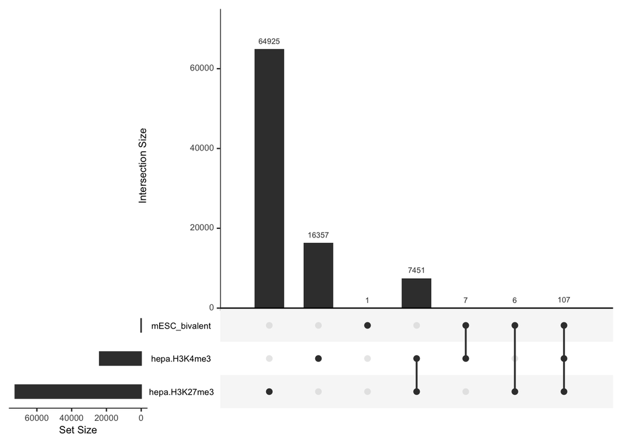

```r
regionUpset(peaks, nsets=length(peaks))
```

The biggest overlap can be seen with the both methylation marks of the hepatocytes, meaning there are still bivalent regions (?). There is also a bigger overlap between the two methylation marks and the bivalent domains, which makes sense as the bivalent eSC peaks take into account both the activating and repressive marks found with the the two respective hepatocyte peak sets.